# Semilandmarks on Curves and Surfaces

Dean Adams, Iowa State University

09 April, 2019

# Generalized Procrustes Analysis

- Align objects to common coordinate system using superimposition (GPA)

$$\small\mathbf{Z}=\frac{1}{CS}\mathbf{(Y-\overline{Y})H}$$

- Standardize ‘nuisance’ parameters ($\small{CS}$, $\small\mathbf{H}$, $\small\mathbf{\overline{Y}}$) as:
  - $\small\mathbf{\overline{Y}}$ = translate centroid to the origin
  - $\small{CS}$ = scale by centroid size
  - $\small\mathbf{H}$ rigid rotation (based on optimal angle using all landmarks)
- Works for both 2-D and 3-D landmarks data
- *THE* fundamental approach for morphometrics

# The Problem with Curves I

- Landmarks provide rigorous quantification of shape
- Some objects have few landmarks, but have defined boundaries (curves) or surfaces

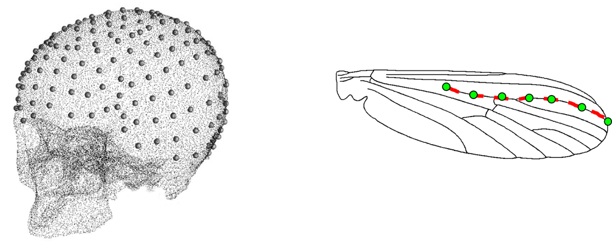

- How do we capture shape information from such structures?

# The Problem with Curves II

- Some objects contain multiple ‘types’ of morphometric data
- Types typically analyzed separately

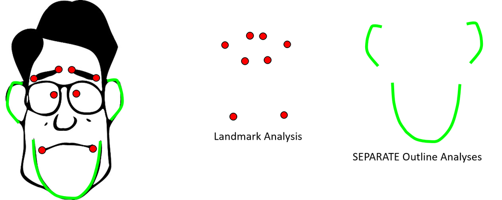

- How do we quantify the overall shape of such structures?

# Mathematically-Defined Points: Problems

- Define landmark homology mathematically (e.g., equal spacing)
- Often produce suggestive (but incorrect) results

# Mathematically-Defined Points: Problems

- Define landmark homology mathematically (e.g., equal spacing)
- Often produce suggestive (but incorrect) results
- Implied shape differences:

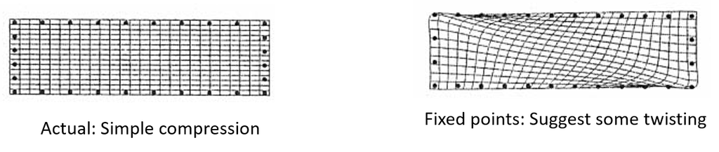

# Mathematically-Defined Points: Problems

- Define landmark homology mathematically (e.g., equal spacing)
- Often produce suggestive (but incorrect) results
- Implied shape differences:

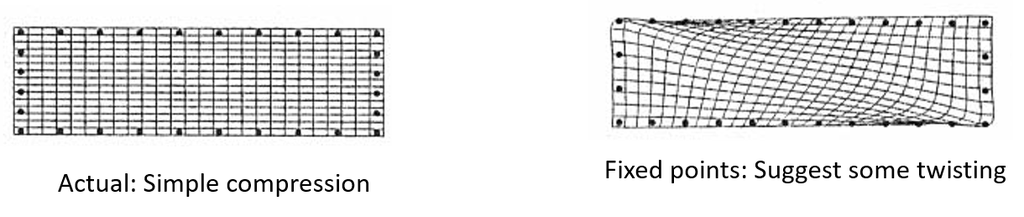

- Can we estimate the shape difference without adding the twisting?

###### Example from: Gunz et al. (2005) in *Modern morphometrics in physical anthropology.*

# Mathematically-Defined Points: Problems (Cont.)

- Another example

# Mathematically-Defined Points: Problems (Cont.)

- Another example
- Implied shape differences:

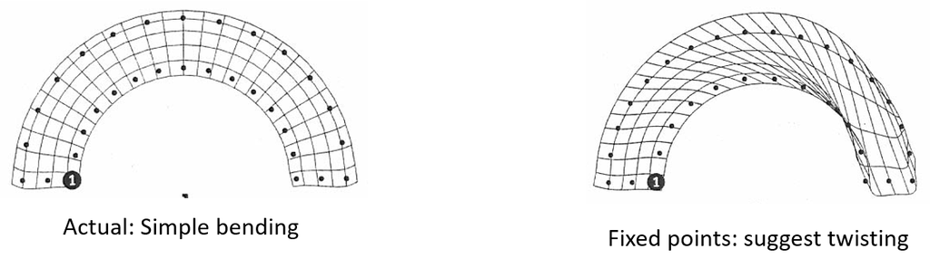

# Mathematically-Defined Points: Problems (Cont.)

- Another example
- Implied shape differences:

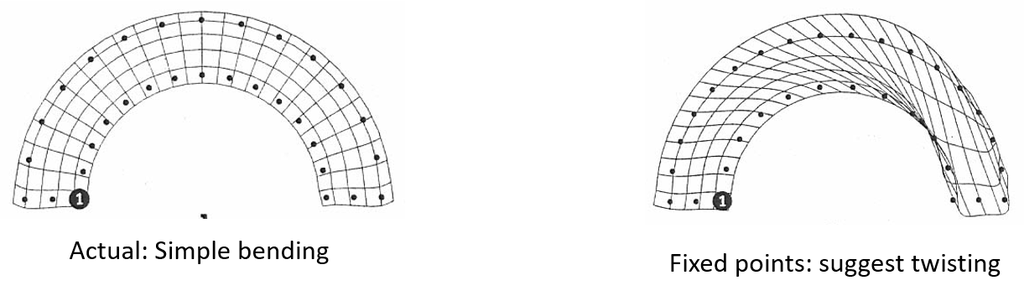

- Can we estimate the shape difference without adding the twisting?

###### Example from: Gunz et al. (2005) in *Modern morphometrics in physical anthropology.*

# Semilandmarks and Procrustes Relaxation

- Procrustes superimposition of 2D points and curves (Bookstein 1997)
- Points along curves are ‘degenerate’ landmarks (semilandmarks)
- Semilandmarks constrained to be on the curve (thus have $\small{\approx{1}}$ df)

# Semilandmarks and Procrustes Relaxation

- Procrustes superimposition of 2D points and curves (Bookstein 1997)
- Points along curves are ‘degenerate’ landmarks (semilandmarks)
- Semilandmarks constrained to be on the curve (thus have $\small{\approx{1}}$ df)
- Digitize a set number of points along an outline, and allow them to ‘slide’ along curve to improve the fit of a specimen to a reference curve: minimize difference between them

# Semilandmarks and Procrustes Relaxation

- Procrustes superimposition of 2D points and curves (Bookstein 1997)
- Points along curves are ‘degenerate’ landmarks (semilandmarks)
- Semilandmarks constrained to be on the curve (thus have $\small{\approx{1}}$ df)
- Digitize a set number of points along an outline, and allow them to ‘slide’ along curve to improve the fit of a specimen to a reference curve: minimize difference between them
- Treat as points for standard landmark analysis (GPA+TPS)

###### Bookstein (1997) *Med. Image Anal.*

# Procrustes Relaxation: Conceptual Procedure

- Incorporate ‘sliding’ of semilandmarks into GPA algorithm
- GPA algorithm with sliding landmarks: Procedure
  - 1: Translate and scale specimens

# Procrustes Relaxation: Conceptual Procedure

- Incorporate ‘sliding’ of semilandmarks into GPA algorithm
- GPA algorithm with sliding landmarks: Procedure
  - 1: Translate and scale specimens
  - 2: LS rotation, find consensus

# Procrustes Relaxation: Conceptual Procedure

- Incorporate ‘sliding’ of semilandmarks into GPA algorithm
- GPA algorithm with sliding landmarks: Procedure
  - 1: Translate and scale specimens
  - 2: LS rotation, find consensus
  - 3: **‘Slide’ landmarks along curve in some way**

# Procrustes Relaxation: Conceptual Procedure

- Incorporate ‘sliding’ of semilandmarks into GPA algorithm
- GPA algorithm with sliding landmarks: Procedure
  - 1: Translate and scale specimens
  - 2: LS rotation, find consensus
  - 3: **‘Slide’ landmarks along curve in some way**
  - 4: Perform GPA to obtain new consensus

# Procrustes Relaxation: Conceptual Procedure

- Incorporate ‘sliding’ of semilandmarks into GPA algorithm
- GPA algorithm with sliding landmarks: Procedure
  - 1: Translate and scale specimens
  - 2: LS rotation, find consensus
  - 3: **‘Slide’ landmarks along curve in some way**
  - 4: Perform GPA to obtain new consensus
  - 5: Iterate steps 2-5 to improve fit

# Procrustes Relaxation: Conceptual Procedure

- Incorporate ‘sliding’ of semilandmarks into GPA algorithm
- GPA algorithm with sliding landmarks: Procedure
  - 1: Translate and scale specimens
  - 2: LS rotation, find consensus
  - 3: **‘Slide’ landmarks along curve in some way**
  - 4: Perform GPA to obtain new consensus
  - 5: Iterate steps 2-5 to improve fit
- Two analytical issues:
  - What direction to slide?
  - How far to slide?

# What Direction to Slide?

- Slide landmarks along curve
- Adjacent points on curve define sliding directions: $\small{U}_{ij}=[(x_j-x_{j+1}),(y_j-y_{j+1})]$

# What Direction to Slide?

- Slide landmarks along curve
- Adjacent points on curve define sliding directions: $\small{U}_{ij}=[(x_j-x_{j+1}),(y_j-y_{j+1})]$
- Assemble into tangent direction matrix

$$\tiny\mathbf{U}=\begin{bmatrix}
0 & 0 & 0 \\
u_{2x} & 0 & 0\\
0 & u_{3x} & 0 \\
0 & 0 & u_{4x} \\
0 & 0 & 0 \\
\hline
0 & 0 & 0 \\
u_{2y} & 0 & 0\\
0 & u_{3y} & 0 \\
0 & 0 & u_{4y} \\
0 & 0 & 0 \\
\end{bmatrix}$$

# What Direction to Slide?

- Slide landmarks along curve
- Adjacent points on curve define sliding directions: $\small{U}_{ij}=[(x_j-x_{j+1}),(y_j-y_{j+1})]$
- Assemble into tangent direction matrix

$$\tiny\mathbf{U}=\begin{bmatrix}
0 & 0 & 0 \\
u_{2x} & 0 & 0\\
0 & u_{3x} & 0 \\
0 & 0 & u_{4x} \\
0 & 0 & 0 \\
\hline
0 & 0 & 0 \\
u_{2y} & 0 & 0\\
0 & u_{3y} & 0 \\
0 & 0 & u_{4y} \\
0 & 0 & 0
\end{bmatrix}$$

- Landmark positions after sliding found as: $\small\mathbf{Y}^*=\mathbf{Y^0-UT}$

# How Far to Slide?

- Most conservative approach: slide to minimize shape differences
- Sliding defined by $\small\mathbf{T}$: $\small\mathbf{Y}^*=\mathbf{Y^0-UT}$
- Two criteria: bending energy ($\small{BE}$) & Procrustes distance ($\small{D}_{Proc}$)

# How Far to Slide?

- Most conservative approach: slide to minimize shape differences
- Sliding defined by $\small\mathbf{T}$: $\small\mathbf{Y}^*=\mathbf{Y^0-UT}$
- Two criteria: bending energy ($\small{BE}$) & Procrustes distance ($\small{D}_{Proc}$)
- 1: Slide landmarks to minimize $\small{BE}$ via **GLS**:
  $$\small\mathbf{T}=(\mathbf{U^T\mathcal{L}_p^{-1}U})^{-1}\mathbf{\mathcal{L}_p^{-1}U^T}(\mathbf{Y^0-Y_{ref}})$$

where $\small\mathbf{\mathcal{L}_p^{-1}}=\begin{bmatrix} \mathbf{L}_p^{-1} & 0 \\ 0 & \mathbf{L}_p^{-1} \end{bmatrix}$

# How Far to Slide?

- Most conservative approach: slide to minimize shape differences
- Sliding defined by $\small\mathbf{T}$: $\small\mathbf{Y}^*=\mathbf{Y^0-UT}$
- Two criteria: bending energy ($\small{BE}$) & Procrustes distance ($\small{D}_{Proc}$)
- 1: Slide landmarks to minimize $\small{BE}$ via **GLS**:
  $$\small\mathbf{T}=(\mathbf{U^T\mathcal{L}_p^{-1}U})^{-1}\mathbf{\mathcal{L}_p^{-1}U^T}(\mathbf{Y^0-Y_{ref}})$$

where $\small\mathbf{\mathcal{L}_p^{-1}}=\begin{bmatrix} \mathbf{L}_p^{-1} & 0 \\ 0 & \mathbf{L}_p^{-1} \end{bmatrix}$

- 2: Slide landmarks to minimize $\small{D}_{Proc}$:
  $$\small\mathbf{T}=\mathbf{U^T}(\mathbf{Y^0-Y_{ref}})$$

###### Note: $\small\mathbf{Y^0}$ and $\small\mathbf{Y_{ref}}$ are assembled by $\small{x}$ then $\small{y}$ coordinates

###### Statistical note: Sliding by $\small{D}_{Proc}$ assumes independence of semilandmarks, as $\small(\mathbf{U^T\mathcal{L}_p^{-1}U})^{-1}\mathcal{L}_p^{-1}=\mathbf{I}$ (this is not realistic).

# Procrustes Relaxation: Flow of Computations

- Sliding incorporated into GPA algorithm

# Procrustes Relaxation: Flow of Computations

- Sliding incorporated into GPA algorithm
  - 1: Translate and scale specimens
  - 2: LS rotation, obtain reference and $\small\mathbf{L}_p^{-1}$

# Procrustes Relaxation: Flow of Computations

- Sliding incorporated into GPA algorithm
  - 1: Translate and scale specimens
  - 2: LS rotation, obtain reference and $\small\mathbf{L}_p^{-1}$
  - 3: Calculate tangent directions $\small\mathbf{U}$
    $$\small{U}_{ij}=[(x_j-x_{j+1}),(y_j-y_{j+1})]$$

# Procrustes Relaxation: Flow of Computations

- Sliding incorporated into GPA algorithm
  - 1: Translate and scale specimens
  - 2: LS rotation, obtain reference and $\small\mathbf{L}_p^{-1}$
  - 3: Calculate tangent directions $\small\mathbf{U}$
    $$\small{U}_{ij}=[(x_j-x_{j+1}),(y_j-y_{j+1})]$$
  - 4: Slide landmarks along tangents using $\small{BE}$ or $\small{D}_{Proc}$
    $$\small\mathbf{T}=(\mathbf{U^T\mathcal{L}_p^{-1}U})^{-1}\mathbf{\mathcal{L}_p^{-1}U^T}(\mathbf{Y^0-Y_{ref}})$$
    $$\small\mathbf{T}=\mathbf{U^T}(\mathbf{Y^0-Y_{ref}})$$

# Procrustes Relaxation: Flow of Computations

- Sliding incorporated into GPA algorithm
  - 1: Translate and scale specimens
  - 2: LS rotation, obtain reference and $\small\mathbf{L}_p^{-1}$
  - 3: Calculate tangent directions $\small\mathbf{U}$
    $$\small{U}_{ij}=[(x_j-x_{j+1}),(y_j-y_{j+1})]$$
  - 4: Slide landmarks along tangents using $\small{BE}$ or $\small{D}_{Proc}$
    $$\small\mathbf{T}=(\mathbf{U^T\mathcal{L}_p^{-1}U})^{-1}\mathbf{\mathcal{L}_p^{-1}U^T}(\mathbf{Y^0-Y_{ref}})$$
    $$\small\mathbf{T}=\mathbf{U^T}(\mathbf{Y^0-Y_{ref}})$$
  - 5: Perform GPA and obtain new reference
  - 6: Iterate 2 - 5 to improve fit

# Semilandmarks: Differing Approaches

- Visual differences between $\small{BE}$ and $\small{D}_{Proc}$ sliding:

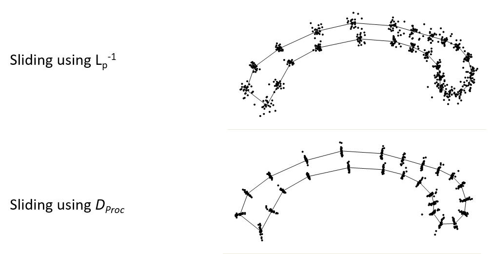

- Mathematical comments: Using $\small{BE}$ is akin to a weighted regression, which accounts for spatial proximity (non-independence) of adjacent landmarks. This is a more reasonable model, as one uses semilandmarks *precisely* to represent curves by an adjacent set of points which are explicitly not independent

# Procruses Relaxation: Refinements

- Semilandmarks slide along tangent directions
- But if slid to far they ‘leave’ the actual curve
- Solution is to project back to curve during GPA + sliding

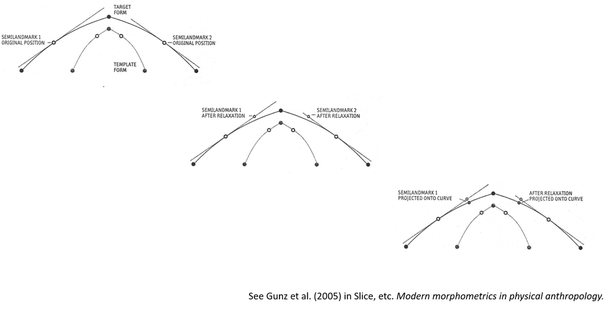

# Combining Points and Curves

- One can allow landmarks to remain ‘fixed’ while semilandmarks slide (e.g. endpoints above)
- Information incorporated into $\small\mathbf{U}$
- Columns of $\small{0}$ represent landmarks that don’t slide

# Combining Points and Curves

- One can allow landmarks to remain ‘fixed’ while semilandmarks slide (e.g., endpoints above)
- Information incorporated into $\small\mathbf{U}$
- Columns of $\small{0}$ represent landmarks that don’t slide

$$\tiny\mathbf{U}=\begin{bmatrix}
0 & 0 & 0 & 0 & 0 \\
0 & u_{2x} & 0 & 0& 0 \\
0 & 0 & u_{3x} & 0 & 0 \\
0 & 0 & 0 & u_{4x} & 0 \\
0 & 0 & 0 & 0 & 0 \\
\hline
0 & 0 & 0 & 0 & 0 \\
0 & u_{2y} & 0 & 0 & 0\\
0 & 0 & u_{3y} & 0 & 0 \\
0 & 0 & 0 & u_{4y} & 0 \\
0 & 0 & 0 & 0 & 0
\end{bmatrix}$$

###### Note: with this notation, generalized inverses are required to complete GLS sliding (and process can be SLOW)

###### Note 2: `geomorph` uses very clever algebra to eliminate redundancies in computations to speed this process up considerably

# Combining Landmarks and Curves: Example

- Cranial profiles in *Homo*
- External differences in frontal bones of archaic and modern humans are well-known
- Archaic humans have ‘frontal flattening’ while modern human crania are more vertically rounded
- Common anthropological interpretation: more-rounded crania in modern humans due to enlargement of frontal lobes of brain
- Profiles of internal and external frontal bones were digitized from 5 mid-Pleistocene and Neanderthal crania, and 16 modern humans and compared

###### Bookstein et al. (1999). Anatomical Record.

# Semilandmark Example: The Data

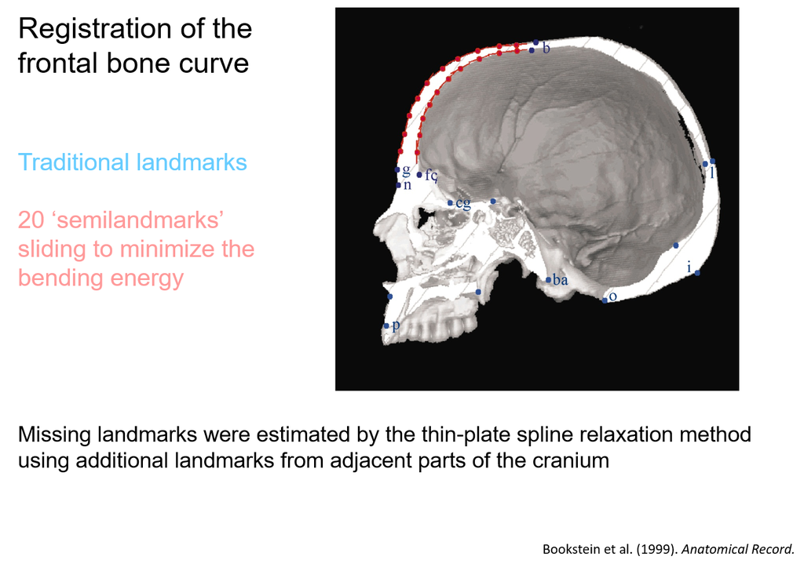

# Semilandmark Example: The Data

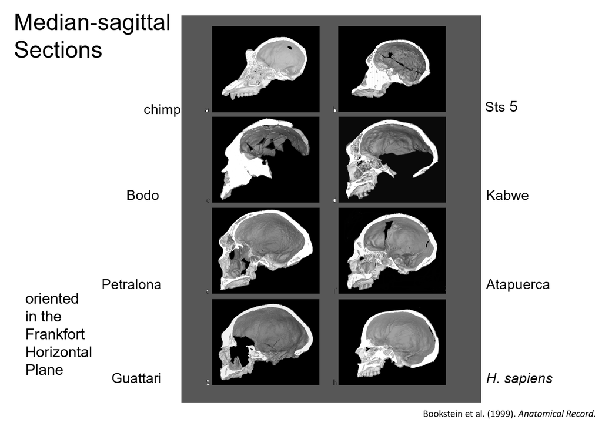

# Semilandmark Example: Results

- Large differences in external profiles, but NO difference of internal profiles

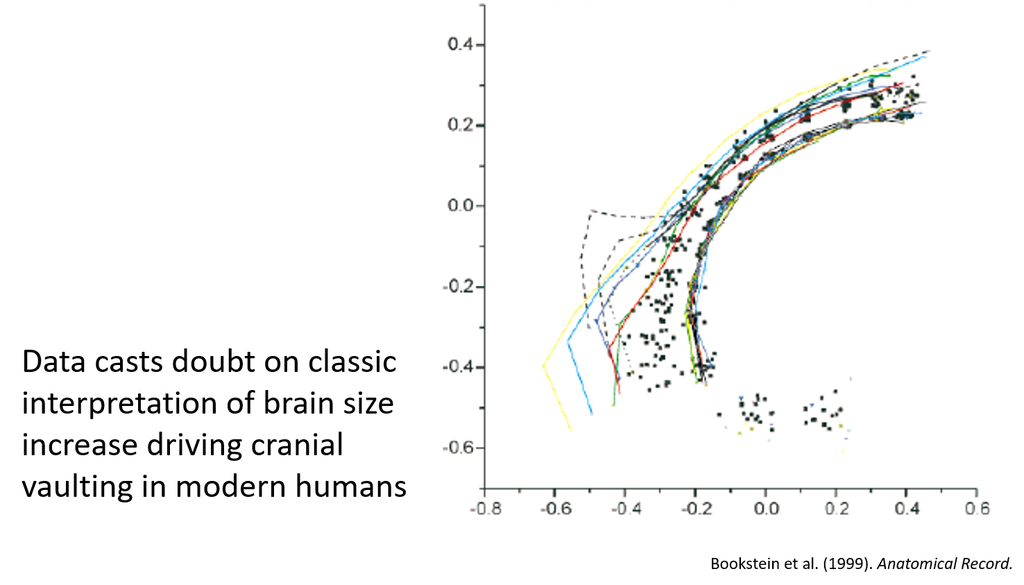

# Semilandmarks on 3D Curves

- Semilandmarks on 3D curves work identically, by defining tangent directions of $\small\Delta{x}$, $\small\Delta{y}$, and $\small\Delta{z}$

$$\tiny\mathbf{U}=\begin{bmatrix}
0 & 0 & 0 \\
u_{2x} & 0 & 0\\
0 & u_{3x} & 0 \\
0 & 0 & u_{4x} \\
0 & 0 & 0 \\
\hline
0 & 0 & 0 \\
u_{2y} & 0 & 0\\
0 & u_{3y} & 0 \\
0 & 0 & u_{4y} \\
0 & 0 & 0 \\
\hline
0 & 0 & 0 \\
u_{2z} & 0 & 0\\
0 & u_{3z} & 0 \\
0 & 0 & u_{4z} \\
0 & 0 & 0
\end{bmatrix}$$

- Slide as before:

$$\tiny\mathbf{T}=(\mathbf{U^T\mathcal{L}_p^{-1}U})^{-1}\mathbf{\mathcal{L}_p^{-1}U^T}(\mathbf{Y^0-Y_{ref}})$$
$$\tiny\mathbf{\mathcal{L}_p^{-1}}=\begin{bmatrix}
\mathbf{L}_p^{-1} & 0 & 0 \\
0 & \mathbf{L}_p^{-1} & 0 \\
0 & 0 & \mathbf{L}_p^{-1}
\end{bmatrix}$$

$$\tiny\mathbf{T}=\mathbf{U^T}(\mathbf{Y^0-Y_{ref}})$$

# Semilandmarks on Surfaces

- 3D surface landmarks slide in the plane
- Plane defined by PC1 & PC2 of surrounding points

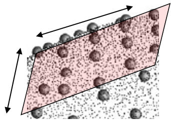

- $\small\mathbf{U}$ has 2 sets of tangent directions Slide using $\small{BE}$ or $\small{D}_{Proc}$ as before

$$\tiny\mathbf{U}=
\left[
\begin{array}{ccc|ccc}
0 & 0 & 0 & 0 & 0 & 0 \\
u_{2x} & 0 & 0 & w_{2x} & 0 & 0 \\
0 & u_{3x} & 0 & 0 & w_{3x} & 0 \\
0 & 0 & u_{4x} & 0 & 0 & w_{4x} \\
0 & 0 & 0 & 0 & 0 & 0\\
\hline
0 & 0 & 0 & 0 & 0 & 0\\
u_{2y} & 0 & 0 & w_{2y} & 0 & 0 \\
0 & u_{3y} & 0 & 0 & w_{3y} & 0 \\
0 & 0 & u_{4y} & 0 & 0 & w_{4y} \\
0 & 0 & 0 & 0 & 0 & 0\\
\hline
0 & 0 & 0 & 0 & 0 & 0\\
u_{2z} & 0 & 0 & w_{2z} & 0 & 0\\
0 & u_{3z} & 0 & 0 & w_{3z} & 0 \\
0 & 0 & u_{4z} & 0 & 0 & w_{4z} \\
0 & 0 & 0 & 0 & 0 & 0 \\
\end{array}
\right]$$

###### NOTE: One can see that these matrices are becoming *VERY* large. That will lead to long computation time (though recall `geomorph` uses clever algorithms to speed this up! [ask Mike!])

# Defining Semilandmarks on Surfaces

- Surface semilandmarks must retain positional correspondence
- How to digitize?
- 1: ‘By hand’ (digitize same set of points from all surfaces)

# Defining Semilandmarks on Surfaces

- Surface semilandmarks must retain positional correspondence, so how to digitize?
- 1: ‘By hand’ (digitize same set of points from all surfaces)
- 2: Semi-automate
  - Digitize many landmarks on surface
  - ‘Thin’ to a reasonable number (150-200) on 1st specimen
  - Match these to surface points of next specimen (using TPS)
  - Repeat

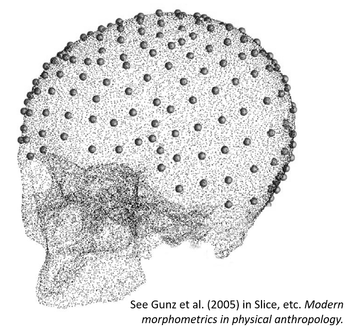

###### Note: resampling methods required for significance testing as $\small{p>>n}$

# Combining Points, Curves, and Surfaces

- Landmarks and semilandmarks can all be combined
  - Digitize points
  - Digitize curve landmarks
  - Digitize surface landmarks
- Define tangent directions and generate **U**
- **GPA + Sliding**

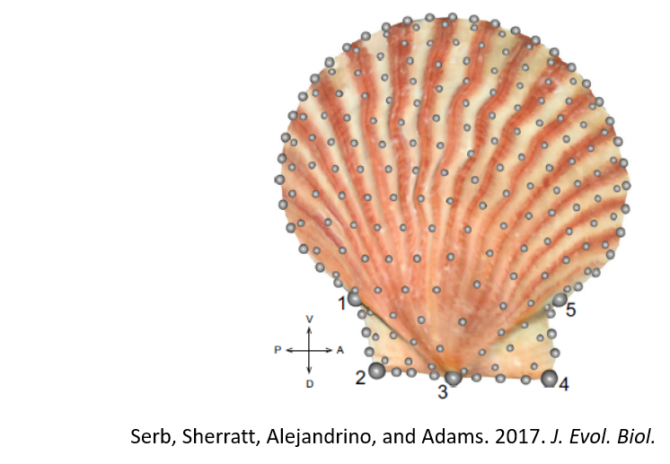

# Complications: Shape Variables and Dimensionality

- Sliding procedure results in redundant shape dimensions
  - Minimum: ~1 df lost per 2D/3D curve semilandmark; and ~2 df lost per 3D surface semilandmark (e.g., ~ $\small{2p-4-m}$ shape variables in 2D for $\small{m}$ = # semilandmarks)
  - However, usually many more dimensions lost, because adjacent semilandmarks encode redundant shape information
- Causes *MAJOR* issues for statistical hypothesis testing using Procrustes residuals

# Complications: Shape Variables and Dimensionality

- Sliding procedure results in redundant shape dimensions
  - Minimum: ~1 df lost per 2D/3D curve semilandmark; and ~2 df lost per 3D surface semilandmark (e.g., ~ $\small{2p-4-m}$ shape variables in 2D for $\small{m}$ = # semilandmarks)
  - However, usually many more dimensions lost, because adjacent semilandmarks encode redundant shape information
- Causes *MAJOR* issues for statistical hypothesis testing using Procrustes residuals
- Solutions:
  - 1: PCA to ‘spin out’ redundant dimensions (remove dimensions with 0.0% variance)
  - 2: Use generalized inverses in computations
  - 3: **Use resampling procedures (RRPP) for significance testing**

###### Note: #3 also required when # shape variables exceeds # specimens

# Semilandmarks: Snake Example

- Examined head shape in snakes (83 species)
- Focused on aquatic species in different families
- Is there evidence of head shape convergence?

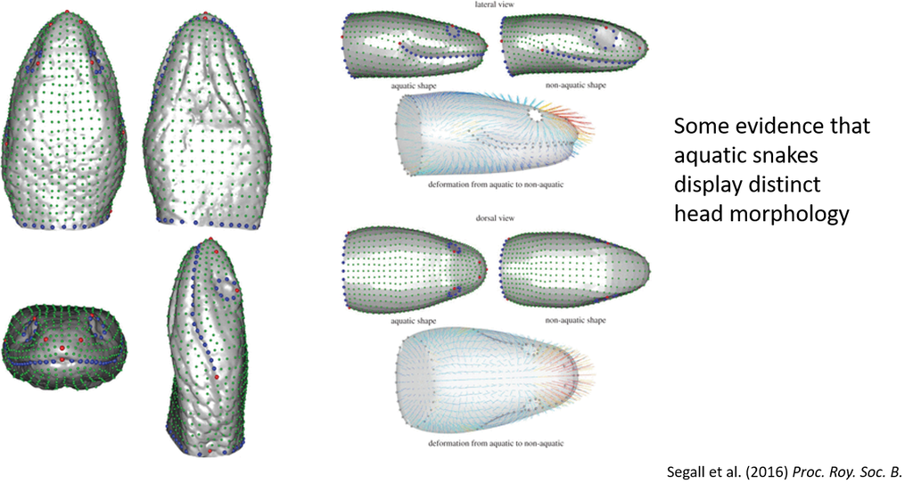

# Semilandmarks: *Homo* Example

- Examined ‘Zuttiyeh’ fossil morphology as compared to other early hominids

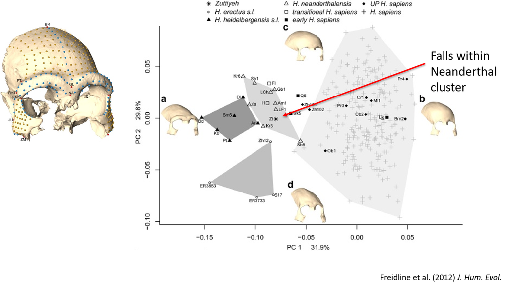

# Semilandmarks: Scallop Example

- Scallop species display differing life habits
- What patterns are observed at the macroevolutionary level?

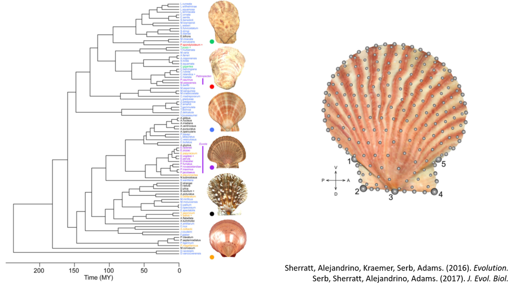

# Semilandmarks: Scallop Example (Cont.)

- Recessors display unique morphology and directional evolution

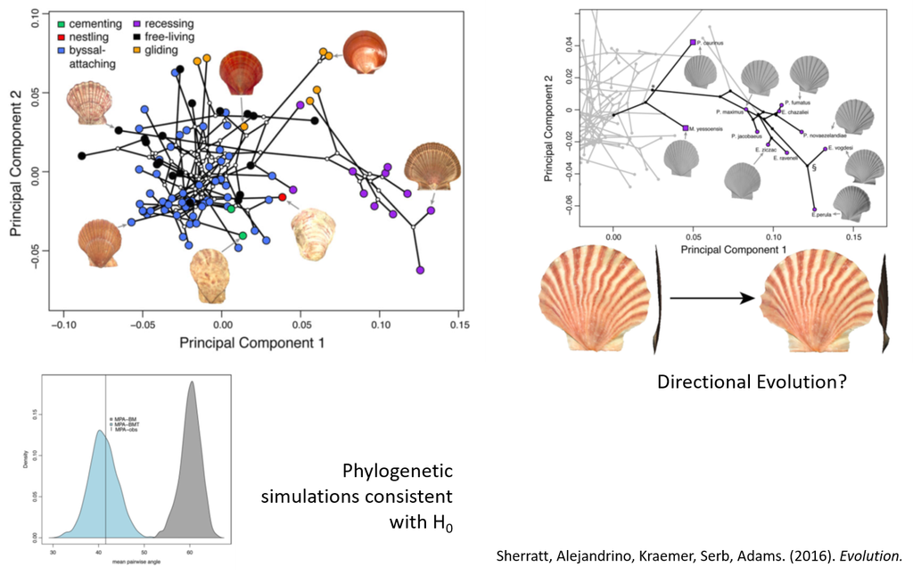

# Semilandmarks: Scallop Example (Cont.)

- Gliders occupy morphological convergence

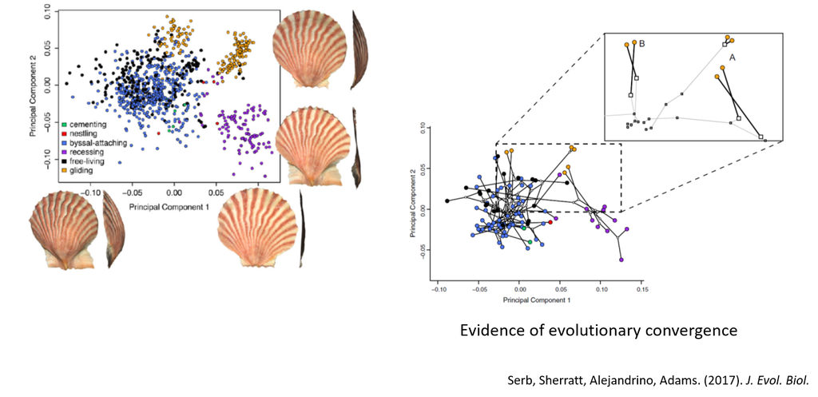

# The Procrustes Paradigm

- With landmarks and semilandmarks we arrive at a general solution for quantifying morphology
- Quantitative information representing:
  - Discrete anatomical points
  - Curves (outlines) of structures
  - Surfaces of structures
- **Can all be combined in a single analysis of shape variation**

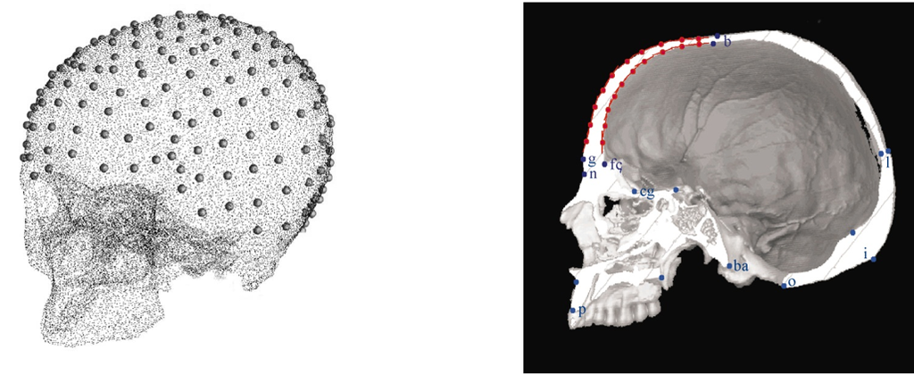